# 542project-Copy1

PUBPOL 542

Draft Deliverable 1: "Prepare data for analytical work using Python".

Elena Popic

Note: All three datasets used in this assignment were imported from the World Bank Open Data (https://data.worldbank.org/), last accessed February 16, 2023.

```python
#Reading-in the datasets into Pandas dataframes from their Github location:

import pandas as pd

gitCloudRepo = 'https://github.com/elenapopic542/Deliverable1/raw/main/'
fileName = "Inflation.Data.csv"

DF1csv = pd.read_csv(gitCloudRepo + fileName)
DF1csv
```

|  | Country Name | Country Code | Series Name | Series Code | 2015 [YR2015] | 2016 [YR2016] | 2017 [YR2017] | 2018 [YR2018] | 2019 [YR2019] | 2020 [YR2020] | 2021 [YR2021] |
| --- | --- | --- | --- | --- | --- | --- | --- | --- | --- | --- | --- |
| 0 | Afghanistan | AFG | Inflation, consumer prices (annual %) | FP.CPI.TOTL.ZG | -0.661709165 | 4.383891955 | 4.975951506 | 0.626149149 | 2.302372515 | .. | .. |
| 1 | Albania | ALB | Inflation, consumer prices (annual %) | FP.CPI.TOTL.ZG | 3.501208355 | -0.36731721 | 2.060598459 | 2.028059631 | 1.41109079 | 1.620886617 | 2.041471631 |
| 2 | Algeria | DZA | Inflation, consumer prices (annual %) | FP.CPI.TOTL.ZG | 4.784447007 | 6.397694803 | 5.59111591 | 4.269990205 | 1.951768211 | 2.415130941 | 7.226063074 |
| 3 | American Samoa | ASM | Inflation, consumer prices (annual %) | FP.CPI.TOTL.ZG | .. | .. | .. | .. | .. | .. | .. |
| 4 | Andorra | AND | Inflation, consumer prices (annual %) | FP.CPI.TOTL.ZG | .. | .. | .. | .. | .. | .. | .. |
| ... | ... | ... | ... | ... | ... | ... | ... | ... | ... | ... | ... |
| 1948 | Virgin Islands (U.S.) | VIR | Exports of goods and services (current LCU) | NE.EXP.GNFS.CN | 1525000000 | 1786000000 | 2403000000 | 2084000000 | 2265000000 | 1621000000 | .. |
| 1949 | West Bank and Gaza | PSE | Exports of goods and services (current LCU) | NE.EXP.GNFS.CN | 2244300000 | 2207100000 | 2536000000 | 2598000000 | 2659300000 | 2385300000 | 3180200000 |
| 1950 | Yemen, Rep. | YEM | Exports of goods and services (current LCU) | NE.EXP.GNFS.CN | 1.7951E+12 | 5.31439E+11 | 8.71433E+11 | 7.01274E+11 | .. | .. | .. |
| 1951 | Zambia | ZMB | Exports of goods and services (current LCU) | NE.EXP.GNFS.CN | 68105000000 | 76335917800 | 86170612100 | 1.04449E+11 | 1.04064E+11 | 1.55448E+11 | 2.30896E+11 |
| 1952 | Zimbabwe | ZWE | Exports of goods and services (current LCU) | NE.EXP.GNFS.CN | 3824969000 | 4098132100 | 4333000000 | 18213653800 | 57633903700 | 3.57343E+11 | 8.10609E+11 |

1953 rows × 11 columns

```python
#Reading-in the datasets into Pandas dataframes from their Github location:
gitCloudRepo = 'https://github.com/elenapopic542/Deliverable1/raw/main/'
fileName = "GDP.Data.csv"

DF2csv = pd.read_csv(gitCloudRepo + fileName)
DF2csv
```

|  | Country Name | Country Code | Series Name | Series Code | 2015 [YR2015] | 2016 [YR2016] | 2017 [YR2017] | 2018 [YR2018] | 2019 [YR2019] | 2020 [YR2020] | 2021 [YR2021] |
| --- | --- | --- | --- | --- | --- | --- | --- | --- | --- | --- | --- |
| 0 | Afghanistan | AFG | GDP growth (annual %) | NY.GDP.MKTP.KD.ZG | 1.45131466 | 2.260314201 | 2.647003202 | 1.189228128 | 3.911603419 | -2.351100673 | -20.73714562 |
| 1 | Albania | ALB | GDP growth (annual %) | NY.GDP.MKTP.KD.ZG | 2.218726375 | 3.314980684 | 3.8022274 | 4.019359685 | 2.088063376 | -3.481630373 | 8.515501123 |
| 2 | Algeria | DZA | GDP growth (annual %) | NY.GDP.MKTP.KD.ZG | 3.7 | 3.2 | 1.3 | 1.2 | 1 | -5.1 | 3.5 |
| 3 | American Samoa | ASM | GDP growth (annual %) | NY.GDP.MKTP.KD.ZG | 3.149606299 | -1.679389313 | -6.98757764 | 2.671118531 | -0.487804878 | 5.065359477 | -1.866251944 |
| 4 | Andorra | AND | GDP growth (annual %) | NY.GDP.MKTP.KD.ZG | 1.434140395 | 3.70967807 | 0.34607189 | 1.58876549 | 2.015547638 | -11.18393994 | 8.949417981 |
| ... | ... | ... | ... | ... | ... | ... | ... | ... | ... | ... | ... |
| 429 | Virgin Islands (U.S.) | VIR | GDP per capita (current US$) | NY.GDP.PCAP.CD | 34007.35294 | 35324.97489 | 35365.0693 | 36653.86305 | 38596.03071 | 39552.1686 | .. |
| 430 | West Bank and Gaza | PSE | GDP per capita (current US$) | NY.GDP.PCAP.CD | 3272.154324 | 3527.613824 | 3620.360487 | 3562.330943 | 3656.858271 | 3233.568638 | 3663.969055 |
| 431 | Yemen, Rep. | YEM | GDP per capita (current US$) | NY.GDP.PCAP.CD | 1488.416482 | 1069.817122 | 893.7165729 | 701.7148778 | .. | .. | .. |
| 432 | Zambia | ZMB | GDP per capita (current US$) | NY.GDP.PCAP.CD | 1307.909649 | 1249.923143 | 1495.752138 | 1475.204538 | 1268.120941 | 956.8313639 | 1137.343633 |
| 433 | Zimbabwe | ZWE | GDP per capita (current US$) | NY.GDP.PCAP.CD | 1410.329174 | 1421.787789 | 1192.107012 | 2269.177012 | 1421.868596 | 1372.696674 | 1773.920411 |

434 rows × 11 columns

```python
#Reading-in the datasets into Pandas dataframes from their Github location:
gitCloudRepo = 'https://github.com/elenapopic542/Deliverable1/raw/main/'
fileName = "GNI.Data.csv"

DF3csv = pd.read_csv(gitCloudRepo + fileName)
DF3csv
```

|  | Country Name | Country Code | Series Name | Series Code | 2015 [YR2015] | 2016 [YR2016] | 2017 [YR2017] | 2018 [YR2018] | 2019 [YR2019] | 2020 [YR2020] | 2021 [YR2021] |
| --- | --- | --- | --- | --- | --- | --- | --- | --- | --- | --- | --- |
| 0 | Afghanistan | AFG | GNI (current US$) | NY.GNP.MKTP.CD | 20178945326 | 18199126228 | 19145017023 | 18610257350 | 19205014965 | 20332384125 | 14910923352 |
| 1 | Albania | ALB | GNI (current US$) | NY.GNP.MKTP.CD | 11521808375 | 12053832974 | 13051480688 | 15137993151 | 15200249154 | 14881636667 | 18006189075 |
| 2 | Algeria | DZA | GNI (current US$) | NY.GNP.MKTP.CD | 1.61667E+11 | 1.58474E+11 | 1.67559E+11 | 1.70507E+11 | 1.67568E+11 | 1.42065E+11 | 1.59458E+11 |
| 3 | American Samoa | ASM | GNI (current US$) | NY.GNP.MKTP.CD | .. | .. | .. | .. | .. | .. | .. |
| 4 | Andorra | AND | GNI (current US$) | NY.GNP.MKTP.CD | .. | .. | .. | .. | 3462263517 | .. | .. |
| ... | ... | ... | ... | ... | ... | ... | ... | ... | ... | ... | ... |
| 646 | Virgin Islands (U.S.) | VIR | GNI growth (annual %) | NY.GNP.MKTP.KD.ZG | .. | .. | .. | .. | .. | .. | .. |
| 647 | West Bank and Gaza | PSE | GNI growth (annual %) | NY.GNP.MKTP.KD.ZG | 5.355109309 | 9.052775313 | 1.840935422 | 4.582756503 | 2.075230317 | -12.60799023 | 9.655758906 |
| 648 | Yemen, Rep. | YEM | GNI growth (annual %) | NY.GNP.MKTP.KD.ZG | .. | .. | .. | .. | .. | .. | .. |
| 649 | Zambia | ZMB | GNI growth (annual %) | NY.GNP.MKTP.KD.ZG | .. | .. | .. | .. | .. | .. | .. |
| 650 | Zimbabwe | ZWE | GNI growth (annual %) | NY.GNP.MKTP.KD.ZG | 0.39354612 | 0.380369391 | 5.221456539 | 15.30434426 | -5.853189546 | -8.40330853 | 8.192465595 |

651 rows × 11 columns

Cleaning the data:

Starting by examining the columns present in each dataframe:

```python
DF1csv.columns
```

```
Index(['Country Name', 'Country Code', 'Series Name', 'Series Code',
       '2015 [YR2015]', '2016 [YR2016]', '2017 [YR2017]', '2018 [YR2018]',
       '2019 [YR2019]', '2020 [YR2020]', '2021 [YR2021]'],
      dtype='object')
```

```python
DF2csv.columns
```

```
Index(['Country Name', 'Country Code', 'Series Name', 'Series Code',
       '2015 [YR2015]', '2016 [YR2016]', '2017 [YR2017]', '2018 [YR2018]',
       '2019 [YR2019]', '2020 [YR2020]', '2021 [YR2021]'],
      dtype='object')
```

```python
DF3csv.columns
```

```
Index(['Country Name', 'Country Code', 'Series Name', 'Series Code',
       '2015 [YR2015]', '2016 [YR2016]', '2017 [YR2017]', '2018 [YR2018]',
       '2019 [YR2019]', '2020 [YR2020]', '2021 [YR2021]'],
      dtype='object')
```

```python
#Preserving a copy of the original file before making any changes
#original_DF1csv = DF1csv
#original_DF2csv = DF2csv
#original_DF3csv = DF3csv
#DF1csv = original_DF1csv
#DF2csv = original_DF2csv
#DF3csv = original_DF3csv
```

Dropping the columns that are not needed for analysis from each of the dataframes:

In this case, I will focus the analysis of various country-level indicators for the year of 2021. Therefore, the observations for the periods preceding the cut-off year (i.e., 2015 - 2020) will be dropped from the analysis.

```python
#Dropping the variables that are irrelevant for our analysis:
DF1csv.drop(columns = DF1csv.columns[4:10],inplace=True)
DF1csv
```

|  | Country Name | Country Code | Series Name | Series Code | 2021 [YR2021] |
| --- | --- | --- | --- | --- | --- |
| 0 | Afghanistan | AFG | Inflation, consumer prices (annual %) | FP.CPI.TOTL.ZG | .. |
| 1 | Albania | ALB | Inflation, consumer prices (annual %) | FP.CPI.TOTL.ZG | 2.041471631 |
| 2 | Algeria | DZA | Inflation, consumer prices (annual %) | FP.CPI.TOTL.ZG | 7.226063074 |
| 3 | American Samoa | ASM | Inflation, consumer prices (annual %) | FP.CPI.TOTL.ZG | .. |
| 4 | Andorra | AND | Inflation, consumer prices (annual %) | FP.CPI.TOTL.ZG | .. |
| ... | ... | ... | ... | ... | ... |
| 1948 | Virgin Islands (U.S.) | VIR | Exports of goods and services (current LCU) | NE.EXP.GNFS.CN | .. |
| 1949 | West Bank and Gaza | PSE | Exports of goods and services (current LCU) | NE.EXP.GNFS.CN | 3180200000 |
| 1950 | Yemen, Rep. | YEM | Exports of goods and services (current LCU) | NE.EXP.GNFS.CN | .. |
| 1951 | Zambia | ZMB | Exports of goods and services (current LCU) | NE.EXP.GNFS.CN | 2.30896E+11 |
| 1952 | Zimbabwe | ZWE | Exports of goods and services (current LCU) | NE.EXP.GNFS.CN | 8.10609E+11 |

1953 rows × 5 columns

```python
#Dropping the variables that are irrelevant for our analysis:
DF2csv.drop(columns = DF2csv.columns[4:10],inplace=True)
DF2csv
```

|  | Country Name | Country Code | Series Name | Series Code | 2021 [YR2021] |
| --- | --- | --- | --- | --- | --- |
| 0 | Afghanistan | AFG | GDP growth (annual %) | NY.GDP.MKTP.KD.ZG | -20.73714562 |
| 1 | Albania | ALB | GDP growth (annual %) | NY.GDP.MKTP.KD.ZG | 8.515501123 |
| 2 | Algeria | DZA | GDP growth (annual %) | NY.GDP.MKTP.KD.ZG | 3.5 |
| 3 | American Samoa | ASM | GDP growth (annual %) | NY.GDP.MKTP.KD.ZG | -1.866251944 |
| 4 | Andorra | AND | GDP growth (annual %) | NY.GDP.MKTP.KD.ZG | 8.949417981 |
| ... | ... | ... | ... | ... | ... |
| 429 | Virgin Islands (U.S.) | VIR | GDP per capita (current US$) | NY.GDP.PCAP.CD | .. |
| 430 | West Bank and Gaza | PSE | GDP per capita (current US$) | NY.GDP.PCAP.CD | 3663.969055 |
| 431 | Yemen, Rep. | YEM | GDP per capita (current US$) | NY.GDP.PCAP.CD | .. |
| 432 | Zambia | ZMB | GDP per capita (current US$) | NY.GDP.PCAP.CD | 1137.343633 |
| 433 | Zimbabwe | ZWE | GDP per capita (current US$) | NY.GDP.PCAP.CD | 1773.920411 |

434 rows × 5 columns

```python
#Dropping the variables that are irrelevant for our analysis:
DF3csv.drop(columns=DF3csv.columns[4:10],inplace=True)
DF3csv
```

|  | Country Name | Country Code | Series Name | Series Code | 2021 [YR2021] |
| --- | --- | --- | --- | --- | --- |
| 0 | Afghanistan | AFG | GNI (current US$) | NY.GNP.MKTP.CD | 14910923352 |
| 1 | Albania | ALB | GNI (current US$) | NY.GNP.MKTP.CD | 18006189075 |
| 2 | Algeria | DZA | GNI (current US$) | NY.GNP.MKTP.CD | 1.59458E+11 |
| 3 | American Samoa | ASM | GNI (current US$) | NY.GNP.MKTP.CD | .. |
| 4 | Andorra | AND | GNI (current US$) | NY.GNP.MKTP.CD | .. |
| ... | ... | ... | ... | ... | ... |
| 646 | Virgin Islands (U.S.) | VIR | GNI growth (annual %) | NY.GNP.MKTP.KD.ZG | .. |
| 647 | West Bank and Gaza | PSE | GNI growth (annual %) | NY.GNP.MKTP.KD.ZG | 9.655758906 |
| 648 | Yemen, Rep. | YEM | GNI growth (annual %) | NY.GNP.MKTP.KD.ZG | .. |
| 649 | Zambia | ZMB | GNI growth (annual %) | NY.GNP.MKTP.KD.ZG | .. |
| 650 | Zimbabwe | ZWE | GNI growth (annual %) | NY.GNP.MKTP.KD.ZG | 8.192465595 |

651 rows × 5 columns

Checking the names of the columns for each of the three dataframes:

```python
DF1csv.columns.to_list()
```

```
['Country Name', 'Country Code', 'Series Name', 'Series Code', '2021 [YR2021]']
```

```python
DF2csv.columns.to_list()
```

```
['Country Name', 'Country Code', 'Series Name', 'Series Code', '2021 [YR2021]']
```

```python
DF3csv.columns.to_list()
```

```
['Country Name', 'Country Code', 'Series Name', 'Series Code', '2021 [YR2021]']
```

In the following lines of code, I am eliminating spaces from column names and saving changes in each of the three data frames used in the analysis:

```python
DF1csv.columns.str.replace(" ","",regex=True)
```

```
Index(['CountryName', 'CountryCode', 'SeriesName', 'SeriesCode',
       '2021[YR2021]'],
      dtype='object')
```

```python
DF2csv.columns.str.replace(" ","",regex=True)
```

```
Index(['CountryName', 'CountryCode', 'SeriesName', 'SeriesCode',
       '2021[YR2021]'],
      dtype='object')
```

```python
DF3csv.columns.str.replace(" ","",regex=True)
```

```
Index(['CountryName', 'CountryCode', 'SeriesName', 'SeriesCode',
       '2021[YR2021]'],
      dtype='object')
```

```python
#Saving the changes in column names:
DF1csv.columns = DF1csv.columns.str.replace(" ","",regex=True)
DF2csv.columns = DF2csv.columns.str.replace(" ","",regex=True)
DF3csv.columns = DF3csv.columns.str.replace(" ","",regex=True)

#Note: regular expressions (i.e., "regex") are text patterns used to automate search within string variables:
```

```python
#Renaming specific columns to simplify the longer strings in the names:
DF1csv.rename(columns={"CountryName":"Country", "SeriesName":"Series", "2021[YR2021]":"YR2021"}, inplace = True)
DF2csv.rename(columns={"CountryName":"Country", "SeriesName":"Series", "2021[YR2021]":"YR2021"}, inplace = True)
DF3csv.rename(columns={"CountryName":"Country", "SeriesName":"Series", "2021[YR2021]":"YR2021"}, inplace = True)

#Checking the implementation result:
DF1csv.columns.to_list()
```

```
['Country', 'CountryCode', 'Series', 'SeriesCode', 'YR2021']
```

```python
#Checking the unique values of the Series variable (first dataframe):
DF1csv.Series.value_counts()
```

```
Inflation, consumer prices (annual %)                                                            217
Labor force participation rate, total (% of total population ages 15+) (modeled ILO estimate)    217
Deposit interest rate (%)                                                                        217
Ease of doing business score (0 = lowest performance to 100 = best performance)                  217
Lending interest rate (%)                                                                        217
Manufacturing, value added (current US$)                                                         217
Market capitalization of listed domestic companies (current US$)                                 217
Imports of goods and services (current US$)                                                      217
Exports of goods and services (current LCU)                                                      217
Name: Series, dtype: int64
```

```python
#Checking the unique values of the Series variable (second dataframe):
DF2csv.Series.value_counts()
```

```
GDP growth (annual %)           217
GDP per capita (current US$)    217
Name: Series, dtype: int64
```

```python
#Checking the unique values of the Series variable (third dataframe):
DF3csv.Series.value_counts()
```

```
GNI (current US$)                     217
GNI per capita (constant 2015 US$)    217
GNI growth (annual %)                 217
Name: Series, dtype: int64
```

In the following, for ease of data processing I will shrink the long strings of the Series variable values:

```python
# Simplifying the values of the string Series variable using a dictionary:
changes = {"Inflation, consumer prices (annual %)":"InflationCPI",
"Labor force participation rate, total (% of total population ages 15+) (modeled ILO estimate)":"EmploymentRate",
"Deposit interest rate (%)":"DepositInterestRate",
"Ease of doing business score (0 = lowest performance to 100 = best performance)":"DoingBusinessScore",
"Lending interest rate (%)":"LendingInterestRate",
"Manufacturing, value added (current US$)":"ManufacturingUSD",
"Market capitalization of listed domestic companies (current US$)":"MarketCapitalizationUSD",
"Imports of goods and services (current US$)":"ImportsUSD",
"Exports of goods and services (current LCU)":"ExportsLCU",
"GDP growth (annual %)":"GDPgrowth",
"GDP per capita (current US$)":"GDPcapita",
"GNI (current US$)":"GNIusd",
"GNI per capita (constant 2015 US$)":"GNIcapita",
"GNI growth (annual %)":"GNIgrowth"}

# Saving changes using the "replace" function:
DF1csv.Series.replace(to_replace=changes,inplace=True)
DF2csv.Series.replace(to_replace=changes,inplace=True)
DF3csv.Series.replace(to_replace=changes,inplace=True)
```

```python
#Checking if the changes in the Series variable were properly implemented across all three dataframes:
DF1csv.Series.value_counts()
```

```
InflationCPI               217
EmploymentRate             217
DepositInterestRate        217
DoingBusinessScore         217
LendingInterestRate        217
ManufacturingUSD           217
MarketCapitalizationUSD    217
ImportsUSD                 217
ExportsLCU                 217
Name: Series, dtype: int64
```

```python
DF2csv.Series.value_counts()
```

```
GDPgrowth    217
GDPcapita    217
Name: Series, dtype: int64
```

```python
DF3csv.Series.value_counts()
```

```
GNIusd       217
GNIcapita    217
GNIgrowth    217
Name: Series, dtype: int64
```

In the following, I am eliminating spaces before the first and last characters in text entry fields:

```python
# Eliminating spaces before the first and last characters in text entry fields:
DF1csv.Country.str.strip()
```

```
0                 Afghanistan
1                     Albania
2                     Algeria
3              American Samoa
4                     Andorra
                ...
1948    Virgin Islands (U.S.)
1949       West Bank and Gaza
1950              Yemen, Rep.
1951                   Zambia
1952                 Zimbabwe
Name: Country, Length: 1953, dtype: object
```

```python
# Eliminating spaces before the first and last characters in text entry fields:
DF1csv.Series.str.strip()
```

```
0       InflationCPI
1       InflationCPI
2       InflationCPI
3       InflationCPI
4       InflationCPI
            ...
1948      ExportsLCU
1949      ExportsLCU
1950      ExportsLCU
1951      ExportsLCU
1952      ExportsLCU
Name: Series, Length: 1953, dtype: object
```

```python
# Eliminating spaces before the first and last characters in text entry fields:
DF2csv.Country.str.strip()
```

```
0                Afghanistan
1                    Albania
2                    Algeria
3             American Samoa
4                    Andorra
               ...
429    Virgin Islands (U.S.)
430       West Bank and Gaza
431              Yemen, Rep.
432                   Zambia
433                 Zimbabwe
Name: Country, Length: 434, dtype: object
```

```python
# Eliminating spaces before the first and last characters in text entry fields:
DF2csv.Series.str.strip()
```

```
0      GDPgrowth
1      GDPgrowth
2      GDPgrowth
3      GDPgrowth
4      GDPgrowth
         ...
429    GDPcapita
430    GDPcapita
431    GDPcapita
432    GDPcapita
433    GDPcapita
Name: Series, Length: 434, dtype: object
```

```python
# Eliminating spaces before the first and last characters in text entry fields:
DF3csv.Country.str.strip()
```

```
0                Afghanistan
1                    Albania
2                    Algeria
3             American Samoa
4                    Andorra
               ...
646    Virgin Islands (U.S.)
647       West Bank and Gaza
648              Yemen, Rep.
649                   Zambia
650                 Zimbabwe
Name: Country, Length: 651, dtype: object
```

```python
# Eliminating spaces before the first and last characters in text entry fields:
DF3csv.Series.str.strip()
```

```
0         GNIusd
1         GNIusd
2         GNIusd
3         GNIusd
4         GNIusd
         ...
646    GNIgrowth
647    GNIgrowth
648    GNIgrowth
649    GNIgrowth
650    GNIgrowth
Name: Series, Length: 651, dtype: object
```

! The above three dataframes have a long shape, and there is more than one observation/row for each unit of analysis (country). In the following, for ease of analysis I will transform the datasets into a wide shape before formatting or integrating the data.

*Note: The reshaping can also be done after concatenation. In this, one approach would be to append the dataframes, given that in the long shape all three of my datasets have columns with an identical name, location and datatype. However, for this assignment, I will use the more complex fuzzy merge operations. So I will first reshape all three dataframes into wide format, and then merge them two by two.

```python
#Transforming the datasets into a wide format so that each development indicator in the Series column is separated into its own column,
#this ensures there is only one observation per country:

wide_DF1 = DF1csv.pivot(index='Country', columns='Series', values='YR2021')
wide_DF1
```

| Series Country | DepositInterestRate | DoingBusinessScore | EmploymentRate | ExportsLCU | ImportsUSD | InflationCPI | LendingInterestRate | ManufacturingUSD | MarketCapitalizationUSD |
| --- | --- | --- | --- | --- | --- | --- | --- | --- | --- |
| Afghanistan | .. | .. | 41.39099884 | .. | .. | .. | .. | 1339800235 | .. |
| Albania | 0.41 | .. | 58.52700043 | 5.78731E+11 | 8016544326 | 2.041471631 | 6.021666667 | 1137448997 | .. |
| Algeria | 1.75 | .. | 40.22299957 | 5.8542E+12 | 43020958891 | 7.226063074 | 8 | 42383485211 | .. |
| American Samoa | .. | .. | .. | 334000000 | 724000000 | .. | .. | .. | .. |
| Andorra | .. | .. | .. | .. | .. | .. | .. | .. | .. |
| ... | ... | ... | ... | ... | ... | ... | ... | ... | ... |
| Virgin Islands (U.S.) | .. | .. | 49.38100052 | .. | .. | .. | .. | .. | .. |
| West Bank and Gaza | 2.238147286 | .. | 41.70000076 | 3180200000 | 10244900000 | 1.237481028 | 5.555242497 | .. | .. |
| Yemen, Rep. | .. | .. | 36.80400085 | .. | .. | .. | .. | .. | .. |
| Zambia | .. | .. | 73.43399811 | 2.30896E+11 | 7511102230 | 22.02123429 | .. | 2087162295 | .. |
| Zimbabwe | 8.059166667 | .. | 83.73600006 | 8.10609E+11 | 8767062802 | 98.54610509 | 45.47666667 | 3530214464 | .. |

217 rows × 9 columns

```python
#Ensuring that the Country is the column's name, and not an index as seen in the above output:

wide_DF1= wide_DF1.reset_index(drop=False).\
             rename_axis(index=None, columns=None)

wide_DF1
```

|  | Country | DepositInterestRate | DoingBusinessScore | EmploymentRate | ExportsLCU | ImportsUSD | InflationCPI | LendingInterestRate | ManufacturingUSD | MarketCapitalizationUSD |
| --- | --- | --- | --- | --- | --- | --- | --- | --- | --- | --- |
| 0 | Afghanistan | .. | .. | 41.39099884 | .. | .. | .. | .. | 1339800235 | .. |
| 1 | Albania | 0.41 | .. | 58.52700043 | 5.78731E+11 | 8016544326 | 2.041471631 | 6.021666667 | 1137448997 | .. |
| 2 | Algeria | 1.75 | .. | 40.22299957 | 5.8542E+12 | 43020958891 | 7.226063074 | 8 | 42383485211 | .. |
| 3 | American Samoa | .. | .. | .. | 334000000 | 724000000 | .. | .. | .. | .. |
| 4 | Andorra | .. | .. | .. | .. | .. | .. | .. | .. | .. |
| ... | ... | ... | ... | ... | ... | ... | ... | ... | ... | ... |
| 212 | Virgin Islands (U.S.) | .. | .. | 49.38100052 | .. | .. | .. | .. | .. | .. |
| 213 | West Bank and Gaza | 2.238147286 | .. | 41.70000076 | 3180200000 | 10244900000 | 1.237481028 | 5.555242497 | .. | .. |
| 214 | Yemen, Rep. | .. | .. | 36.80400085 | .. | .. | .. | .. | .. | .. |
| 215 | Zambia | .. | .. | 73.43399811 | 2.30896E+11 | 7511102230 | 22.02123429 | .. | 2087162295 | .. |
| 216 | Zimbabwe | 8.059166667 | .. | 83.73600006 | 8.10609E+11 | 8767062802 | 98.54610509 | 45.47666667 | 3530214464 | .. |

217 rows × 10 columns

```python
#Repeating the above operations for the second dataframe:
wide_DF2 = DF2csv.pivot(index='Country', columns='Series', values='YR2021')
wide_DF2

wide_DF2= wide_DF2.reset_index(drop=False).\
             rename_axis(index=None, columns=None)

wide_DF2
```

|  | Country | GDPcapita | GDPgrowth |
| --- | --- | --- | --- |
| 0 | Afghanistan | 368.7546142 | -20.73714562 |
| 1 | Albania | 6492.872012 | 8.515501123 |
| 2 | Algeria | 3690.627878 | 3.5 |
| 3 | American Samoa | 15743.31076 | -1.866251944 |
| 4 | Andorra | 42137.32727 | 8.949417981 |
| ... | ... | ... | ... |
| 212 | Virgin Islands (U.S.) | .. | .. |
| 213 | West Bank and Gaza | 3663.969055 | 7.050450938 |
| 214 | Yemen, Rep. | .. | .. |
| 215 | Zambia | 1137.343633 | 4.598734039 |
| 216 | Zimbabwe | 1773.920411 | 8.468016898 |

217 rows × 3 columns

```python
#Repeating the above operations for the third dataframe:
wide_DF3 = DF3csv.pivot(index='Country', columns='Series', values='YR2021')
wide_DF3

wide_DF3= wide_DF3.reset_index(drop=False).\
             rename_axis(index=None, columns=None)

wide_DF3
```

|  | Country | GNIcapita | GNIgrowth | GNIusd |
| --- | --- | --- | --- | --- |
| 0 | Afghanistan | .. | .. | 14910923352 |
| 1 | Albania | .. | .. | 18006189075 |
| 2 | Algeria | 3845.982851 | 3.151486116 | 1.59458E+11 |
| 3 | American Samoa | .. | .. | .. |
| 4 | Andorra | .. | .. | .. |
| ... | ... | ... | ... | ... |
| 212 | Virgin Islands (U.S.) | .. | .. | .. |
| 213 | West Bank and Gaza | 3620.045421 | 9.655758906 | 21434600000 |
| 214 | Yemen, Rep. | .. | .. | .. |
| 215 | Zambia | .. | .. | 20225790733 |
| 216 | Zimbabwe | 1250.748746 | 8.192465595 | 27672250575 |

217 rows × 4 columns

To identify mismatches in data formatting, we start by examining the types of data in each of our three dataframes:

```python
#Examining the types of data in the first dataframe:
wide_DF1.info()
```

```
<class 'pandas.core.frame.DataFrame'>
RangeIndex: 217 entries, 0 to 216
Data columns (total 10 columns):
 #   Column                   Non-Null Count  Dtype
---  ------                   --------------  -----
 0   Country                  217 non-null    object
 1   DepositInterestRate      217 non-null    object
 2   DoingBusinessScore       217 non-null    object
 3   EmploymentRate           217 non-null    object
 4   ExportsLCU               217 non-null    object
 5   ImportsUSD               217 non-null    object
 6   InflationCPI             217 non-null    object
 7   LendingInterestRate      217 non-null    object
 8   ManufacturingUSD         217 non-null    object
 9   MarketCapitalizationUSD  217 non-null    object
dtypes: object(10)
memory usage: 17.1+ KB
```

```python
#Examining the types of data in the second dataframe:
wide_DF2.info()
```

```
<class 'pandas.core.frame.DataFrame'>
RangeIndex: 217 entries, 0 to 216
Data columns (total 3 columns):
 #   Column     Non-Null Count  Dtype
---  ------     --------------  -----
 0   Country    217 non-null    object
 1   GDPcapita  217 non-null    object
 2   GDPgrowth  217 non-null    object
dtypes: object(3)
memory usage: 5.2+ KB
```

```python
#Examining the types of data in the third dataframe:
wide_DF3.info()
```

```
<class 'pandas.core.frame.DataFrame'>
RangeIndex: 217 entries, 0 to 216
Data columns (total 4 columns):
 #   Column     Non-Null Count  Dtype
---  ------     --------------  -----
 0   Country    217 non-null    object
 1   GNIcapita  217 non-null    object
 2   GNIgrowth  217 non-null    object
 3   GNIusd     217 non-null    object
dtypes: object(4)
memory usage: 6.9+ KB
```

Data formatting: Based on the above output, I notice that all variables aside from country are in fact numeric, but reflected as objects. In the following lines of code, I will format these data to numeric type.

```python
#Formatting the numeric data (first dataframe):

where=wide_DF1.columns[1:]
wide_DF1[where]=wide_DF1.loc[:,where].apply(pd.to_numeric,errors='coerce')

wide_DF1.info()
```

```
<class 'pandas.core.frame.DataFrame'>
RangeIndex: 217 entries, 0 to 216
Data columns (total 10 columns):
 #   Column                   Non-Null Count  Dtype
---  ------                   --------------  -----
 0   Country                  217 non-null    object
 1   DepositInterestRate      109 non-null    float64
 2   DoingBusinessScore       0 non-null      float64
 3   EmploymentRate           187 non-null    float64
 4   ExportsLCU               167 non-null    float64
 5   ImportsUSD               166 non-null    float64
 6   InflationCPI             157 non-null    float64
 7   LendingInterestRate      107 non-null    float64
 8   ManufacturingUSD         163 non-null    float64
 9   MarketCapitalizationUSD  0 non-null      float64
dtypes: float64(9), object(1)
memory usage: 17.1+ KB
```

```python
#Formatting the numeric data (second dataframe):

where2=wide_DF2.columns[1:]
wide_DF2[where2]=wide_DF2.loc[:,where2].apply(pd.to_numeric,errors='coerce')

wide_DF2.info()
```

```
<class 'pandas.core.frame.DataFrame'>
RangeIndex: 217 entries, 0 to 216
Data columns (total 3 columns):
 #   Column     Non-Null Count  Dtype
---  ------     --------------  -----
 0   Country    217 non-null    object
 1   GDPcapita  197 non-null    float64
 2   GDPgrowth  196 non-null    float64
dtypes: float64(2), object(1)
memory usage: 5.2+ KB
```

```python
#Formatting the numeric data (third dataframe):

where3=wide_DF3.columns[1:]
wide_DF3[where3]=wide_DF3.loc[:,where3].apply(pd.to_numeric,errors='coerce')

wide_DF3.info()
```

```
<class 'pandas.core.frame.DataFrame'>
RangeIndex: 217 entries, 0 to 216
Data columns (total 4 columns):
 #   Column     Non-Null Count  Dtype
---  ------     --------------  -----
 0   Country    217 non-null    object
 1   GNIcapita  139 non-null    float64
 2   GNIgrowth  135 non-null    float64
 3   GNIusd     187 non-null    float64
dtypes: float64(3), object(1)
memory usage: 6.9+ KB
```

```python
#Checking which cells have missing values in the first dataframe:
wide_DF1[wide_DF1.isna().any(axis=1)]
```

|  | Country | DepositInterestRate | DoingBusinessScore | EmploymentRate | ExportsLCU | ImportsUSD | InflationCPI | LendingInterestRate | ManufacturingUSD | MarketCapitalizationUSD |
| --- | --- | --- | --- | --- | --- | --- | --- | --- | --- | --- |
| 0 | Afghanistan | NaN | NaN | 41.390999 | NaN | NaN | NaN | NaN | 1.339800e+09 | NaN |
| 1 | Albania | 0.410000 | NaN | 58.527000 | 5.787310e+11 | 8.016544e+09 | 2.041472 | 6.021667 | 1.137449e+09 | NaN |
| 2 | Algeria | 1.750000 | NaN | 40.223000 | 5.854200e+12 | 4.302096e+10 | 7.226063 | 8.000000 | 4.238349e+10 | NaN |
| 3 | American Samoa | NaN | NaN | NaN | 3.340000e+08 | 7.240000e+08 | NaN | NaN | NaN | NaN |
| 4 | Andorra | NaN | NaN | NaN | NaN | NaN | NaN | NaN | NaN | NaN |
| ... | ... | ... | ... | ... | ... | ... | ... | ... | ... | ... |
| 212 | Virgin Islands (U.S.) | NaN | NaN | 49.381001 | NaN | NaN | NaN | NaN | NaN | NaN |
| 213 | West Bank and Gaza | 2.238147 | NaN | 41.700001 | 3.180200e+09 | 1.024490e+10 | 1.237481 | 5.555242 | NaN | NaN |
| 214 | Yemen, Rep. | NaN | NaN | 36.804001 | NaN | NaN | NaN | NaN | NaN | NaN |
| 215 | Zambia | NaN | NaN | 73.433998 | 2.308960e+11 | 7.511102e+09 | 22.021234 | NaN | 2.087162e+09 | NaN |
| 216 | Zimbabwe | 8.059167 | NaN | 83.736000 | 8.106090e+11 | 8.767063e+09 | 98.546105 | 45.476667 | 3.530214e+09 | NaN |

217 rows × 10 columns

```python
#Dropping additional columns that are not relevant for my analysis:
wide_DF1.drop(columns=['MarketCapitalizationUSD', 'DoingBusinessScore', 'DepositInterestRate', 'LendingInterestRate', 'ExportsLCU'], inplace=True)
```

```python
#Checking which cells have missing values in the second dataframe:
wide_DF2[wide_DF2.isna().any(axis=1)]
```

|  | Country | GDPcapita | GDPgrowth |
| --- | --- | --- | --- |
| 27 | British Virgin Islands | NaN | NaN |
| 39 | Channel Islands | NaN | NaN |
| 49 | Cuba | NaN | 1.254093 |
| 61 | Eritrea | NaN | NaN |
| 65 | Faroe Islands | 69010.30980 | NaN |
| 75 | Gibraltar | NaN | NaN |
| 77 | Greenland | NaN | NaN |
| 94 | Isle of Man | NaN | NaN |
| 103 | Korea, Dem. People's Rep. | NaN | NaN |
| 106 | Kuwait | NaN | NaN |
| 114 | Liechtenstein | NaN | NaN |
| 140 | New Caledonia | 37159.54677 | NaN |
| 146 | Northern Mariana Islands | NaN | NaN |
| 164 | San Marino | NaN | NaN |
| 172 | Sint Maarten (Dutch part) | NaN | NaN |
| 178 | South Sudan | NaN | NaN |
| 183 | St. Martin (French part) | NaN | NaN |
| 189 | Syrian Arab Republic | NaN | NaN |
| 199 | Turkmenistan | NaN | NaN |
| 210 | Venezuela, RB | NaN | NaN |
| 212 | Virgin Islands (U.S.) | NaN | NaN |
| 214 | Yemen, Rep. | NaN | NaN |

```python
#Checking which cells have missing values in the third dataframe:
wide_DF3[wide_DF3.isna().any(axis=1)]
```

|  | Country | GNIcapita | GNIgrowth | GNIusd |
| --- | --- | --- | --- | --- |
| 0 | Afghanistan | NaN | NaN | 1.491092e+10 |
| 1 | Albania | NaN | NaN | 1.800619e+10 |
| 3 | American Samoa | NaN | NaN | NaN |
| 4 | Andorra | NaN | NaN | NaN |
| 6 | Antigua and Barbuda | NaN | NaN | 1.454600e+09 |
| ... | ... | ... | ... | ... |
| 208 | Uzbekistan | NaN | NaN | 6.943490e+10 |
| 210 | Venezuela, RB | NaN | NaN | NaN |
| 212 | Virgin Islands (U.S.) | NaN | NaN | NaN |
| 214 | Yemen, Rep. | NaN | NaN | NaN |
| 215 | Zambia | NaN | NaN | 2.022579e+10 |

83 rows × 4 columns

As per the above results, missing values are correctly labeled as NaN.

Not all development indicators are reported by each country, which is one plausible explanation for the presence of missing values in my dataset. At this point, my analysis will not be affected by deleting the missing data.

*Note: In other cases it would be useful to carefully examine the nature of missing data and identify suitable strategies for imputing or replacing the missing values as pointed out by Magallanes (2017).

```python
#Dropping the missing data:
wide_DF1.dropna(inplace=True)

#Resetting the index
wide_DF1.reset_index(drop=True, inplace=True)
wide_DF1
```

|  | Country | EmploymentRate | ImportsUSD | InflationCPI | ManufacturingUSD |
| --- | --- | --- | --- | --- | --- |
| 0 | Albania | 58.527000 | 8.016544e+09 | 2.041472 | 1.137449e+09 |
| 1 | Algeria | 40.223000 | 4.302096e+10 | 7.226063 | 4.238349e+10 |
| 2 | Angola | 76.459000 | 1.091771e+10 | 25.754266 | 3.484027e+09 |
| 3 | Armenia | 51.914001 | 6.075565e+09 | 7.184836 | 1.580781e+09 |
| 4 | Australia | 65.748001 | 2.762950e+11 | 2.863910 | 8.615494e+10 |
| ... | ... | ... | ... | ... | ... |
| 122 | Uruguay | 61.671001 | 1.502196e+10 | 7.747914 | 6.317874e+09 |
| 123 | Uzbekistan | 57.723000 | 2.779484e+10 | 10.849240 | 1.383049e+10 |
| 124 | Vietnam | 74.446999 | 3.411540e+11 | 1.834716 | 9.013366e+10 |
| 125 | Zambia | 73.433998 | 7.511102e+09 | 22.021234 | 2.087162e+09 |
| 126 | Zimbabwe | 83.736000 | 8.767063e+09 | 98.546105 | 3.530214e+09 |

127 rows × 5 columns

```python
#Repeating the above operation for the second dataframe:
wide_DF2.dropna(inplace=True)

#Resetting the index
wide_DF2.reset_index(drop=True, inplace=True)
wide_DF2
```

|  | Country | GDPcapita | GDPgrowth |
| --- | --- | --- | --- |
| 0 | Afghanistan | 368.754614 | -20.737146 |
| 1 | Albania | 6492.872012 | 8.515501 |
| 2 | Algeria | 3690.627878 | 3.500000 |
| 3 | American Samoa | 15743.310760 | -1.866252 |
| 4 | Andorra | 42137.327270 | 8.949418 |
| ... | ... | ... | ... |
| 190 | Vanuatu | 2996.621062 | 0.449256 |
| 191 | Vietnam | 3756.489121 | 2.561551 |
| 192 | West Bank and Gaza | 3663.969055 | 7.050451 |
| 193 | Zambia | 1137.343633 | 4.598734 |
| 194 | Zimbabwe | 1773.920411 | 8.468017 |

195 rows × 3 columns

```python
#Repeating the above operation for the third dataframe:
wide_DF3.dropna(inplace=True)

#Resetting the index
wide_DF3.reset_index(drop=True, inplace=True)
wide_DF3
```

|  | Country | GNIcapita | GNIgrowth | GNIusd |
| --- | --- | --- | --- | --- |
| 0 | Algeria | 3845.982851 | 3.151486 | 1.594580e+11 |
| 1 | Angola | 2055.829899 | 0.124624 | 6.208035e+10 |
| 2 | Argentina | 12141.731500 | 11.005341 | 4.774120e+11 |
| 3 | Armenia | 4403.935556 | 4.249692 | 1.345505e+10 |
| 4 | Austria | 44927.009070 | 4.103377 | 4.825280e+11 |
| ... | ... | ... | ... | ... |
| 129 | Uruguay | 14472.649290 | 0.827125 | 5.435961e+10 |
| 130 | Vanuatu | 2860.427476 | 0.281095 | 1.049443e+09 |
| 131 | Vietnam | 3227.558998 | 1.651792 | 3.473880e+11 |
| 132 | West Bank and Gaza | 3620.045421 | 9.655759 | 2.143460e+10 |
| 133 | Zimbabwe | 1250.748746 | 8.192466 | 2.767225e+10 |

134 rows × 4 columns

```python
#Preparing for integration. Checking unique values of the variable encoding country names:
#wide_DF1['Country'].unique()
```

```python
#wide_DF2['Country'].unique()
```

```python
#wide_DF3['Country'].unique()
```

In the following lines, I will proceed to merging the dataframes two by two. For this operation, one column in each dataframe should have the same unique values (in this case, the Country column).

```python
#Examining the shape of the first two dataframes:
wide_DF1.shape,wide_DF2.shape
```

```
((127, 5), (195, 3))
```

Based on the above output, the optimal scenario is for the merged dataframe to have 127 rows.

```python
#Merging the two dataframes:
wide_DF1.merge(wide_DF2).shape
```

```
(127, 7)
```

```python
#The merged dataframe has exactly 127 rows, as expected, which means that all the country names were
#exactly the same in the two dataframes. I save the result as merge1 dataframe:

merge1=wide_DF1.merge(wide_DF2)
```

```python
#Verifying:
merge1.info()
```

```
<class 'pandas.core.frame.DataFrame'>
Int64Index: 127 entries, 0 to 126
Data columns (total 7 columns):
 #   Column            Non-Null Count  Dtype
---  ------            --------------  -----
 0   Country           127 non-null    object
 1   EmploymentRate    127 non-null    float64
 2   ImportsUSD        127 non-null    float64
 3   InflationCPI      127 non-null    float64
 4   ManufacturingUSD  127 non-null    float64
 5   GDPcapita         127 non-null    float64
 6   GDPgrowth         127 non-null    float64
dtypes: float64(6), object(1)
memory usage: 7.9+ KB
```

```python
#Given that all countries were correctly merged, I proceed to the second merge operation so as to integrate the last dataframe.
#I start again by examining the shape of the relevant dataframes:

merge1.shape,wide_DF3.shape
```

```
((127, 7), (134, 4))
```

```python
#Based on the above output, the optimal scenario is for the merged dataframe to have 127 rows.

merge1.merge(wide_DF3).shape
```

```
(109, 10)
```

```python
#Not all countries were matched during the merge. In the following, I identify these countries:

Onlymerge1=set(merge1.Country)-set(wide_DF3.Country)
Onlymerge1
```

```
{'Albania',
 'Australia',
 'Azerbaijan',
 'Fiji',
 'Iceland',
 'Iran, Islamic Rep.',
 'Lesotho',
 'Niger',
 'Qatar',
 'Saudi Arabia',
 'Singapore',
 'Slovak Republic',
 'Switzerland',
 'Tanzania',
 'Thailand',
 'Turkiye',
 'Uzbekistan',
 'Zambia'}
```

```python
#Not all countries were matched during the merge. In the following, I identify these countries:

Onlywide_DF3=set(wide_DF3.Country)-set(merge1.Country)
Onlywide_DF3
```

```
{'Argentina',
 'Bermuda',
 'Bulgaria',
 'Burundi',
 'Canada',
 'Chad',
 'Comoros',
 'Congo, Dem. Rep.',
 'Congo, Rep.',
 "Cote d'Ivoire",
 'Equatorial Guinea',
 'Eswatini',
 'Gabon',
 'Kazakhstan',
 'Kosovo',
 'Madagascar',
 'Marshall Islands',
 'Myanmar',
 'Puerto Rico',
 'Senegal',
 'Seychelles',
 'Sudan',
 'Timor-Leste',
 'Vanuatu',
 'West Bank and Gaza'}
```

```python
#Using the fuzzy merge approach to identify matches between Onlywide_DF3 and Onlymerge1.

from thefuzz import process as fz
[(fz.extractOne(merge1, Onlywide_DF3), merge1) for merge1 in sorted(Onlymerge1)]
```

```
[(('Bulgaria', 53), 'Albania'),
 (('Equatorial Guinea', 54), 'Australia'),
 (('Kazakhstan', 50), 'Azerbaijan'),
 (("Cote d'Ivoire", 45), 'Fiji'),
 (('Marshall Islands', 64), 'Iceland'),
 (('Congo, Rep.', 86), 'Iran, Islamic Rep.'),
 (('Timor-Leste', 60), 'Lesotho'),
 (('Congo, Rep.', 51), 'Niger'),
 (('Equatorial Guinea', 54), 'Qatar'),
 (('Sudan', 54), 'Saudi Arabia'),
 (('Gabon', 54), 'Singapore'),
 (('Congo, Rep.', 45), 'Slovak Republic'),
 (('Canada', 45), 'Switzerland'),
 (('Canada', 57), 'Tanzania'),
 (('Marshall Islands', 58), 'Thailand'),
 (('Burundi', 43), 'Turkiye'),
 (('Kazakhstan', 60), 'Uzbekistan'),
 (('Myanmar', 46), 'Zambia')]
```

```python
#The above results did not identify any good matches.
#To confirm, I'm checking the countries with the highest similarity score:

[(fz.extractOne(merge1, Onlywide_DF3),merge1)
 for merge1 in sorted(Onlymerge1)
 if fz.extractOne(merge1, Onlywide_DF3)[1]>=86] #86 is the highest similarity score received above
```

```
[(('Congo, Rep.', 86), 'Iran, Islamic Rep.')]
```

```python
#The above result is not a good match.
#Saving the final merged dataframe:
merge2=merge1.merge(wide_DF3)
```

```python
#Verifying the data types:
merge2.info()
```

```
<class 'pandas.core.frame.DataFrame'>
Int64Index: 109 entries, 0 to 108
Data columns (total 10 columns):
 #   Column            Non-Null Count  Dtype
---  ------            --------------  -----
 0   Country           109 non-null    object
 1   EmploymentRate    109 non-null    float64
 2   ImportsUSD        109 non-null    float64
 3   InflationCPI      109 non-null    float64
 4   ManufacturingUSD  109 non-null    float64
 5   GDPcapita         109 non-null    float64
 6   GDPgrowth         109 non-null    float64
 7   GNIcapita         109 non-null    float64
 8   GNIgrowth         109 non-null    float64
 9   GNIusd            109 non-null    float64
dtypes: float64(9), object(1)
memory usage: 9.4+ KB
```

```python
#Checking the summary statistics:
merge2.describe()
```

|  | EmploymentRate | ImportsUSD | InflationCPI | ManufacturingUSD | GDPcapita | GDPgrowth | GNIcapita | GNIgrowth | GNIusd |
| --- | --- | --- | --- | --- | --- | --- | --- | --- | --- |
| count | 109.000000 | 1.090000e+02 | 109.000000 | 1.090000e+02 | 109.000000 | 109.000000 | 109.000000 | 109.000000 | 1.090000e+02 |
| mean | 59.936789 | 1.967574e+11 | 7.068127 | 1.188636e+11 | 16888.599468 | 6.105006 | 14193.438180 | 5.451865 | 7.330215e+11 |
| std | 9.719049 | 4.940013e+11 | 17.404288 | 5.273067e+11 | 23132.270763 | 5.251999 | 18204.689502 | 5.360774 | 2.854554e+12 |
| min | 38.131001 | 2.855029e+08 | -0.391347 | 2.434743e+07 | 461.137490 | -7.084588 | 395.546636 | -7.042930 | 4.954124e+08 |
| 25% | 54.752998 | 9.377987e+09 | 2.204572 | 1.676979e+09 | 3293.233054 | 3.610613 | 2793.844612 | 2.894834 | 1.745991e+10 |
| 50% | 60.167999 | 2.675130e+10 | 3.925603 | 7.862141e+09 | 6228.267309 | 5.100128 | 5871.409556 | 4.928792 | 6.388702e+10 |
| 75% | 64.709999 | 1.413510e+11 | 5.862782 | 4.938213e+10 | 21148.162940 | 7.929668 | 17360.160190 | 7.765465 | 3.825940e+11 |
| max | 83.736000 | 3.401360e+12 | 154.756096 | 4.865830e+12 | 133590.147000 | 41.745101 | 83229.219290 | 38.692940 | 2.361710e+13 |

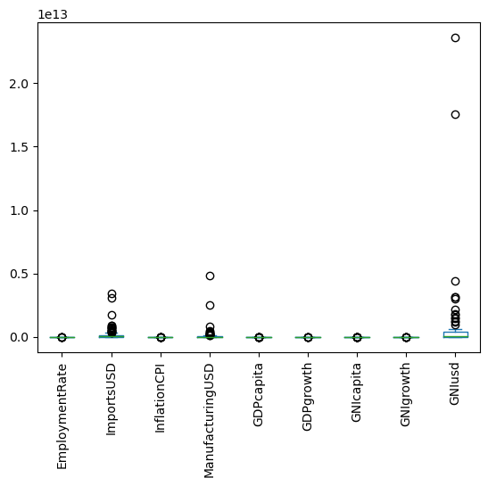

```python
#Creating a boxplot to check for value ranges:
merge2.plot(kind='box', rot=90)
```

Based on the above boxplot, we observe that not all variables in the dataframe are in the same range.

In the following lines of code, I uniformize the range of values for all the variables in the dataframe using the sklearn package.

```python
import sklearn
from sklearn import preprocessing

#Creating a MinMaxScaler object based on the desired range of values
scaler = preprocessing.MinMaxScaler(feature_range=(0, 1))

# Since multiple variables in the dataframe are out of the desired range, I will not create arrays for each variable,
# but rather create an array of all columns containing numeric variables in the merge2 dataset using the above scaler
numeric_cols = merge2.columns[1:10]
array = scaler.fit_transform(merge2[numeric_cols])

print(array.shape)
```

```
(109, 9)
```

```python
#Checking the datatype
type(array)
```

```
numpy.ndarray
```

```python
#Replacing the values of the numeric variables with the above defined array:
merge2[numeric_cols] = array
```

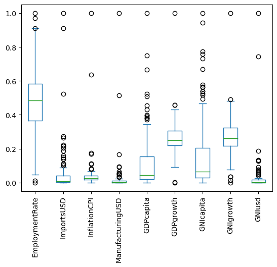

```python
#Re-creating the boxplot:
merge2.plot(kind='box', rot=90)
```

Having finished the data cleaning, formatting and merging operations, we proceed to exporting the file into an R dataframe.

```python
#Saving the Pandas dataframe as an RDS file using the rpy2 package:
import rpy2
from rpy2.robjects import pandas2ri
pandas2ri.activate()

from rpy2.robjects.packages import importr

base = importr('base')
base.saveRDS(merge2,file="wbdata.RDS")
```

```
rpy2.rinterface.NULL
```